# Tafeng_project

Vincent

2023-12-28

##### 讀進資料

```r
Z = read_csv("data/ta_feng_all_months_merged.csv") %>%
  data.frame %>% setNames(c(
    "date","cust","age","area","cat","prod","qty","cost","price"))
load("data/tf0.rdata")# X:交易資料 A:顧客資料
```

## 市場分析

### 市場區隔_地區

1.居住Z115(南港區)、Z221 (汐止區)的顧客最多  
2.其貢獻的毛利最多，購買毛利貢獻前20大品項的數量最多  
##### 各地區客人分布長條圖

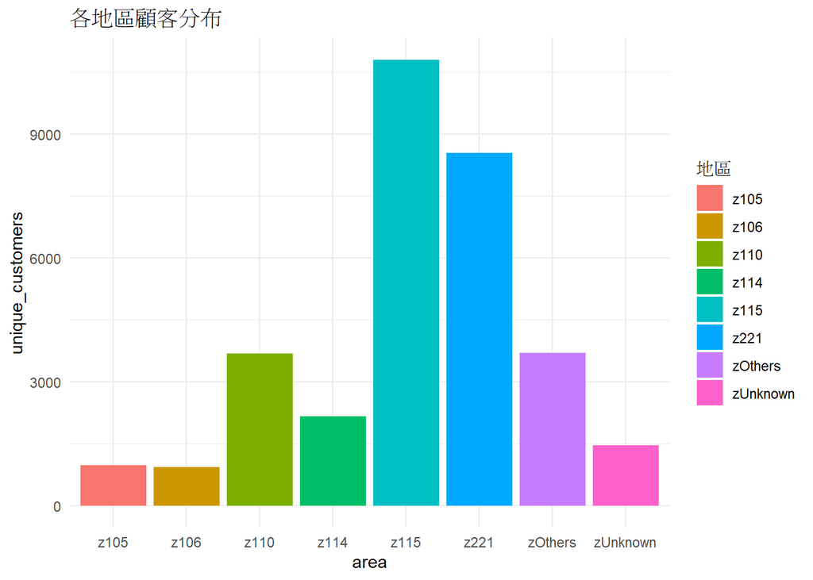

```r
grouped_data <- A0 %>%
  group_by(area) %>%
  summarise(unique_customers = n_distinct(cust))

ggplot(grouped_data, aes(x = area, y = unique_customers, fill = area)) +
  geom_bar(stat = "identity") +
  labs(title = "各地區顧客分布", fill = "地區") +
  theme_minimal()
```

##### 依地區區分的購物數量與毛利之點狀圖

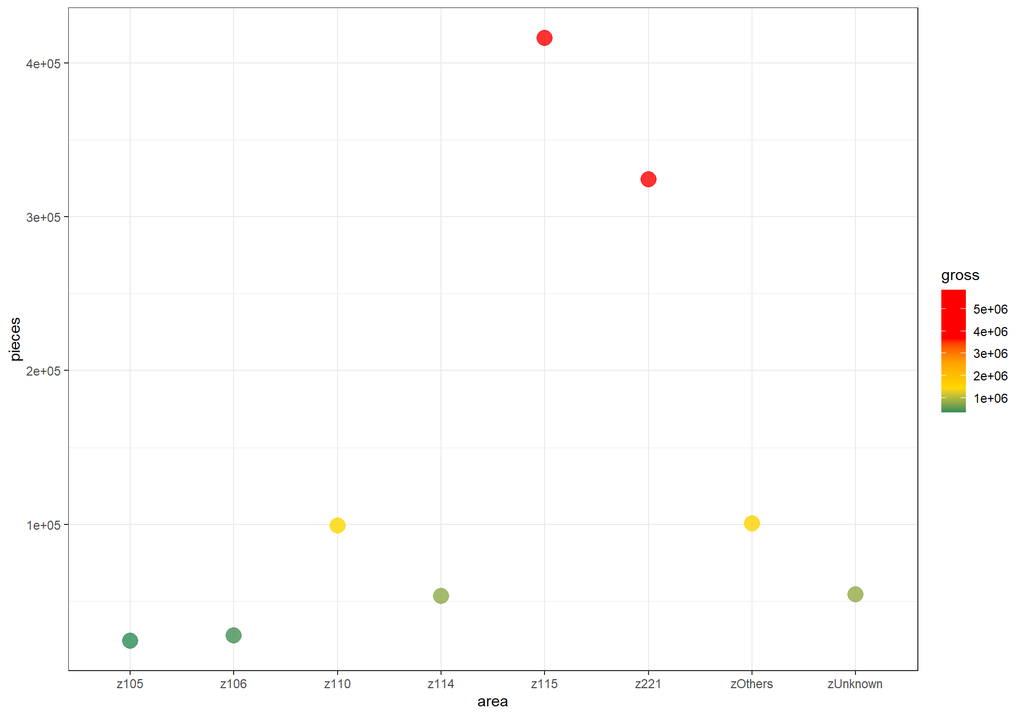

```r
col6 = c('seagreen', 'gold', 'orange', rep('red',3))
gg_areagross = group_by(X0, area) %>% summarise(pieces = sum(pieces), gross = sum(gross)) %>% ggplot(aes(x=area, y=pieces, col=gross, label = area)) + geom_point(size=5, alpha=0.8) + scale_color_gradientn(colors=col6) + theme_bw()

gg_areagross
```

### 市場區隔_年齡

1.年齡34~44歲族群貢獻的毛利最多，購買毛利貢獻前20大品項的數量最多

##### 依年齡區分的購買品項數量分布點狀圖

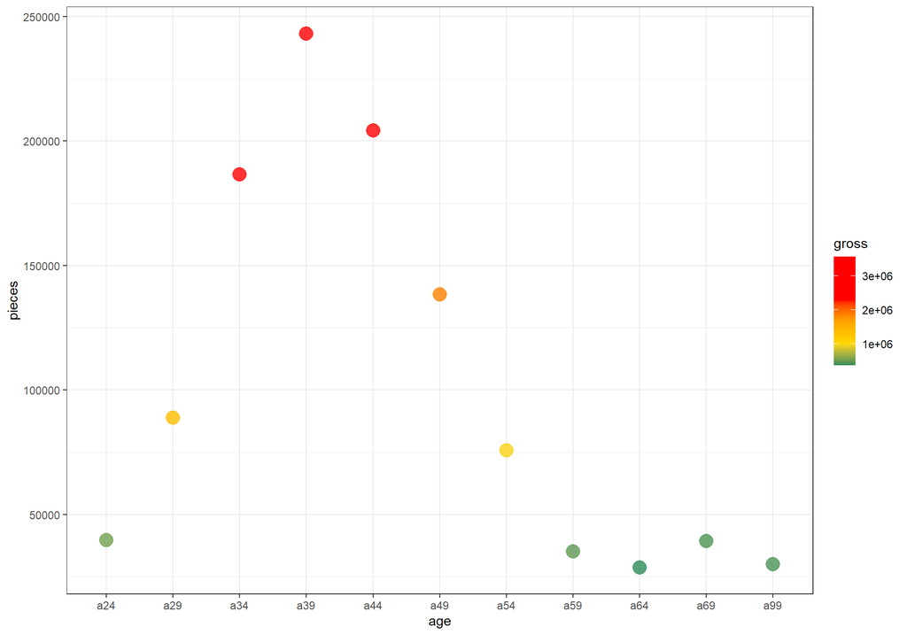

```r
col6 = c('seagreen', 'gold', 'orange', rep('red',3))
gg_agegross = group_by(Z0, age) %>% summarise(solds = n(), pieces = sum(qty), gross = sum(price - cost)) %>% ggplot(aes(x=age, y=pieces, col=gross, label = age)) + geom_point(size=5, alpha=0.8) +  scale_color_gradientn(colors=col6) + theme_bw() + theme_bw()

gg_agegross
```

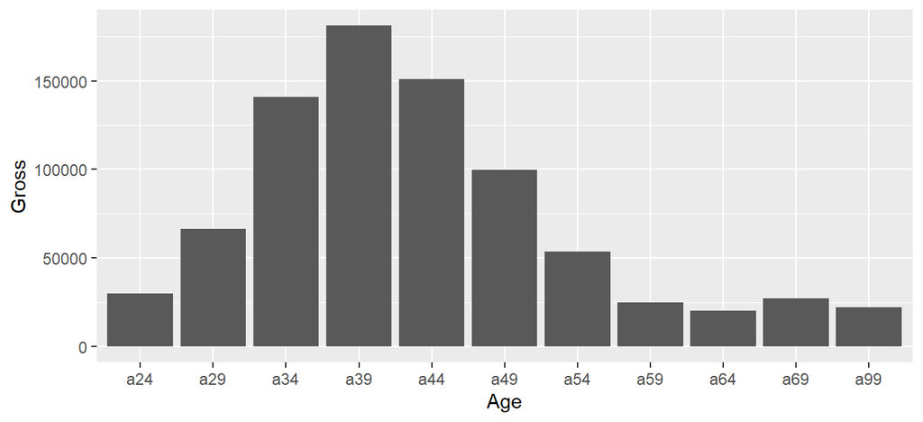

```r
#Z$gross = Z$price - Z$cost
g_gross = group_by(Z0, age) %>% mutate(gross = sum(price- cost)) %>% ggplot(aes(x= age)) + geom_bar() + labs(x = "Age",y = "Gross")
g_gross
```

1.34~44歲族群，購買頻率較少、平均客單價較高  
2.65~69歲族群，購買頻率較高、平均客單價較低

##### 年齡區隔特徵泡泡圖

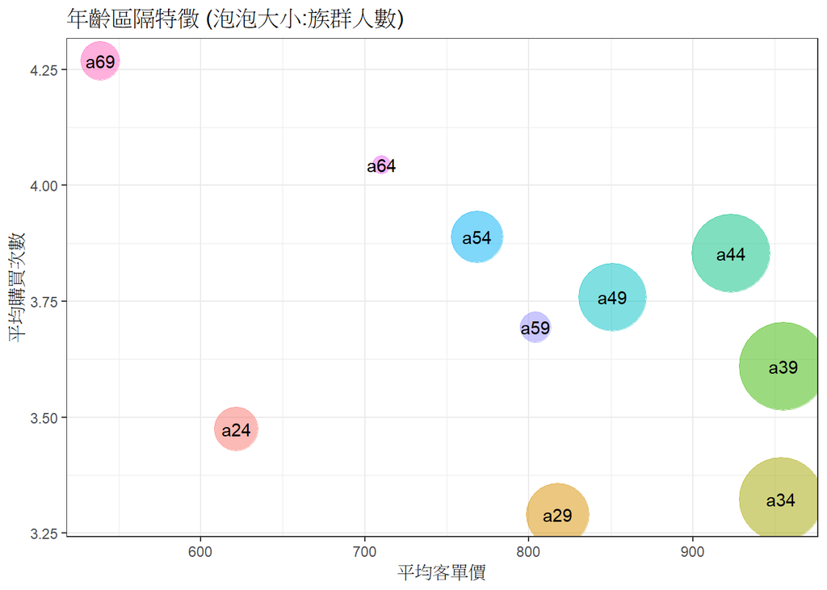

```r
A0 %>% filter(age!="a99") %>%    # 濾掉沒有年齡資料的顧客('a99')
  group_by(age) %>% summarise(
  Group.Size = n(),              # 族群人數
  avg.Freq = mean(f),            # 平均購買次數
  avg.Revenue = sum(f*m)/sum(f)  # 平均客單價
  ) %>%
  ggplot(aes(y=avg.Freq, x=avg.Revenue)) +
  geom_point(aes(col=age, size=Group.Size), alpha=0.5) +
  geom_text(aes(label=age)) +
  scale_size(range=c(5,25)) +
  theme_bw() + theme(legend.position="none") +
  ggtitle("年齡區隔特徵 (泡泡大小:族群人數)") +
  ylab("平均購買次數") + xlab("平均客單價")
```

## 目標客群

##### 使用馬賽克圖檢視列連表的關聯性(Association between Categorial Variables)

- 方塊大小代表該類別組合的數量
- 紅(藍)色代表該類別組合的數量顯著小(大)於期望值
- 期望值就是邊際機率(如上方的直條圖所示)的乘積
- 卡方檢定(類別變數的關聯性檢定)的p值顯示在圖示最下方
- `p-value < 2.22e-16` : `age` 與 `area` 之間有顯著的關聯性

```r
MOSA = function(formula, data) mosaic(formula, data, shade=T,
  margins=c(0,1,0,0), labeling_args = list(rot_labels=c(0,0,0,0)),
  gp_labels=gpar(fontsize=9), legend_args=list(fontsize=9),
  gp_text=gpar(fontsize=7),labeling=labeling_residuals)
```

```r
MOSA2 = function(formula, data) mosaic(formula, data, shade=T,
  margins=c(0,0,0,0), labeling_args = list(rot_labels=c(270,0,0,0)),
  gp_labels=gpar(fontsize=9), legend_args=list(fontsize=9),
  gp_text=gpar(fontsize=7),labeling=labeling_residuals)
```

##### 年齡和地區的關聯統計

1.34~44歲族群主要居住在 Z221 (汐止)、z114 (內湖)  
2.69歲族群主要居住在Z115(南港)

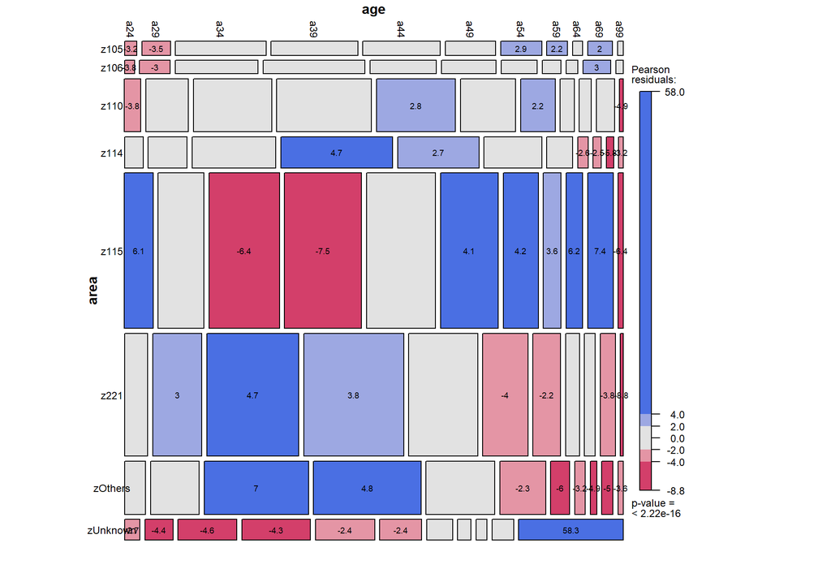

```r
MOSA2(~area+age, data=A0)
```

##### 年齡與購物日的關聯統計

1.34~44歲族群購買行為多集中假日  
2.65~69歲購買行為偏好平日，避開假日人潮

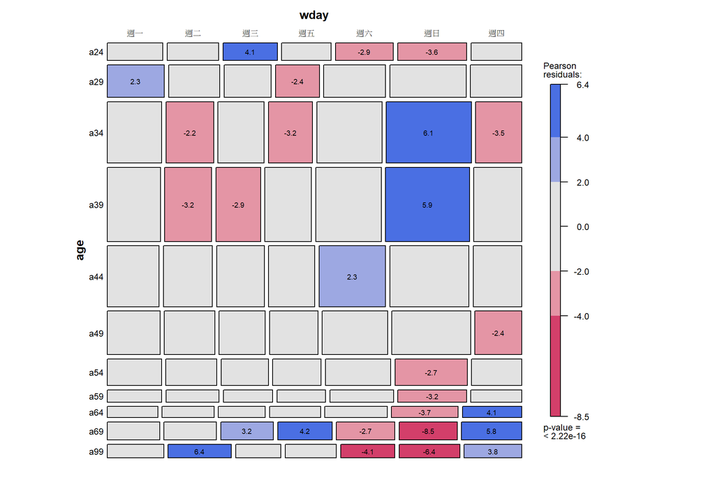

```r
#X0$wday = format(X0$date, "%u")
X0$wday = format(X0$date, "%a")
MOSA(~age+wday, X0)
```

##### 前十大毛利品類長條圖

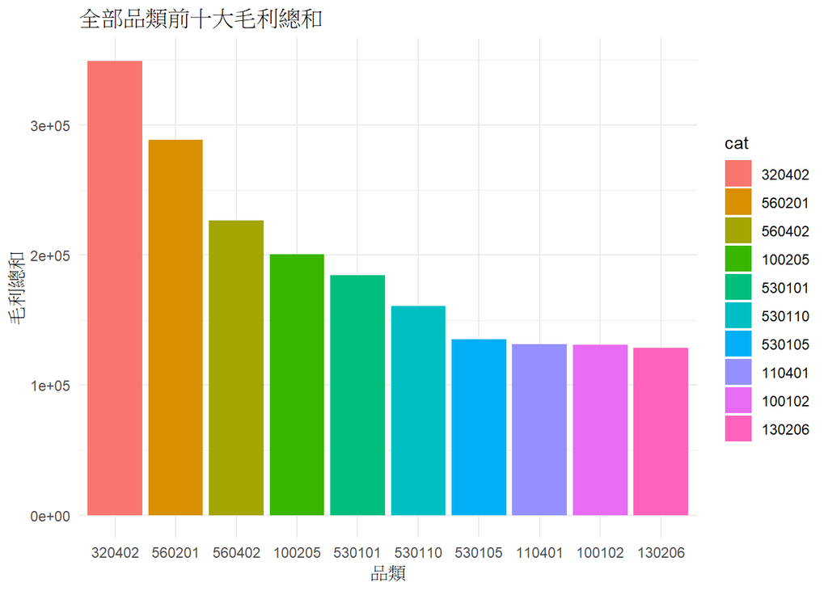

```r
sorted_profit <- Z0 %>%
  mutate(profit = price - cost) %>%
  group_by(cat) %>%
  summarise(total_profit = sum(profit)) %>%
  arrange(desc(total_profit)) %>%
  head(10)

sorted_profit$cat <- factor(sorted_profit$cat, levels = sorted_profit$cat[order(sorted_profit$total_profit, decreasing = TRUE)])

# 使用 ggplot 繪製長條圖
ggplot(sorted_profit, aes(x = cat, y = total_profit, fill = cat)) +
  geom_bar(stat = "identity") +
  labs(title = "全部品類前十大毛利總和", x = "品類", y = "毛利總和") +
  theme_minimal()
```

##### 年齡和品類的關聯統計

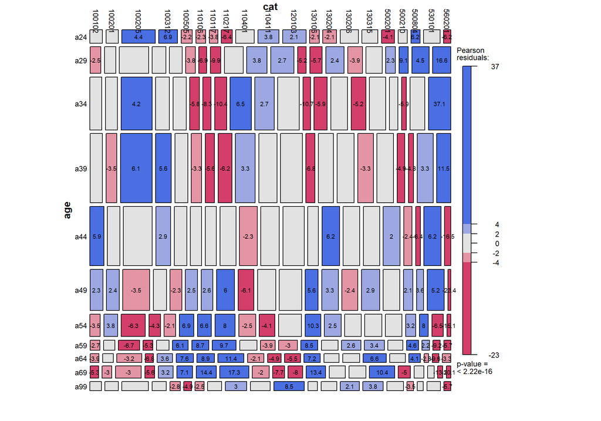

```r
top20 = tapply(Z0$qty,Z0$cat,sum) %>% sort %>% tail(20) %>% names
MOSA2(~age+cat, Z0[Z0$cat %in% top20,])
```

## 策略分析

目標族群：年齡34~44歲族群(青壯、中年人) 年齡65~69歲族群(老年人)  
客群特性：  
主要居住在Z221(汐止區),z114(內湖),zOthrs，z115(南港)  
主要購物日為周末(青壯、中年人)、避開假日人潮(老年人)  
主要購買品類為560201保健食品、110217養生茶  
青壯、中年人:購買頻率較少、平均客單價較高 ->推測都集中在假日大量買、住離店家較遠  
老年人:購買頻率高、平均客單價較低 ->避開假日人潮，多在平日

策略：提高此青壯、中年人族群的購買頻率，並維持其顧客黏著度；提高老年族群平均單價